# Risk Factor Analysis

## Outcome Variable

**Outcome Variable:** swasted

## Predictor Variables

**Intervention Variable:** hdlvry

**Adjustment Set:**

- arm
- sex
- W_mage
- meducyrs
- feducyrs
- hhwealth_quart
- single
- W_nrooms
- brthmon
- W_parity
- impsan
- delta_W_mage
- delta_meducyrs
- delta_feducyrs
- delta_hhwealth_quart
- delta_single
- delta_W_nrooms
- delta_brthmon
- delta_W_parity
- delta_impsan

## Stratifying Variables

The analysis was stratified on these variable(s):

- agecat
- studyid
- country

## Data Summary

| agecat | studyid | country | hdlvry | swasted | n_cell | n |
| --- | --- | --- | --- | --- | --- | --- |
| Birth | ki1000108-CMC-V-BCS-2002 | INDIA | 0 | 0 | 85 | 86 |
| Birth | ki1000108-CMC-V-BCS-2002 | INDIA | 0 | 1 | 1 | 86 |
| Birth | ki1000108-CMC-V-BCS-2002 | INDIA | 1 | 0 | 0 | 86 |
| Birth | ki1000108-CMC-V-BCS-2002 | INDIA | 1 | 1 | 0 | 86 |
| Birth | ki1000108-IRC | INDIA | 0 | 0 | 285 | 343 |
| Birth | ki1000108-IRC | INDIA | 0 | 1 | 52 | 343 |
| Birth | ki1000108-IRC | INDIA | 1 | 0 | 4 | 343 |
| Birth | ki1000108-IRC | INDIA | 1 | 1 | 2 | 343 |
| Birth | ki1000109-EE | PAKISTAN | 0 | 0 | 117 | 175 |
| Birth | ki1000109-EE | PAKISTAN | 0 | 1 | 3 | 175 |
| Birth | ki1000109-EE | PAKISTAN | 1 | 0 | 52 | 175 |
| Birth | ki1000109-EE | PAKISTAN | 1 | 1 | 3 | 175 |
| Birth | ki1000304b-SAS-CompFeed | INDIA | 0 | 0 | 107 | 957 |
| Birth | ki1000304b-SAS-CompFeed | INDIA | 0 | 1 | 1 | 957 |
| Birth | ki1000304b-SAS-CompFeed | INDIA | 1 | 0 | 824 | 957 |
| Birth | ki1000304b-SAS-CompFeed | INDIA | 1 | 1 | 25 | 957 |
| Birth | ki1017093b-PROVIDE | BANGLADESH | 0 | 0 | 378 | 532 |
| Birth | ki1017093b-PROVIDE | BANGLADESH | 0 | 1 | 9 | 532 |
| Birth | ki1017093b-PROVIDE | BANGLADESH | 1 | 0 | 141 | 532 |
| Birth | ki1017093b-PROVIDE | BANGLADESH | 1 | 1 | 4 | 532 |
| Birth | ki1017093c-NIH-Crypto | BANGLADESH | 0 | 0 | 515 | 707 |
| Birth | ki1017093c-NIH-Crypto | BANGLADESH | 0 | 1 | 33 | 707 |
| Birth | ki1017093c-NIH-Crypto | BANGLADESH | 1 | 0 | 145 | 707 |
| Birth | ki1017093c-NIH-Crypto | BANGLADESH | 1 | 1 | 14 | 707 |
| Birth | ki1113344-GMS-Nepal | NEPAL | 0 | 0 | 135 | 596 |
| Birth | ki1113344-GMS-Nepal | NEPAL | 0 | 1 | 8 | 596 |
| Birth | ki1113344-GMS-Nepal | NEPAL | 1 | 0 | 437 | 596 |
| Birth | ki1113344-GMS-Nepal | NEPAL | 1 | 1 | 16 | 596 |
| Birth | ki1135781-COHORTS | INDIA | 0 | 0 | 2642 | 4389 |
| Birth | ki1135781-COHORTS | INDIA | 0 | 1 | 121 | 4389 |

[output cut: 98 more lines]

The following strata were considered:

- agecat: 24 months, studyid: ki1000108-CMC-V-BCS-2002, country: INDIA
- agecat: 24 months, studyid: ki1000108-IRC, country: INDIA
- agecat: 24 months, studyid: ki1000109-EE, country: PAKISTAN
- agecat: 24 months, studyid: ki1017093b-PROVIDE, country: BANGLADESH
- agecat: 24 months, studyid: ki1017093c-NIH-Crypto, country: BANGLADESH
- agecat: 24 months, studyid: ki1066203-TanzaniaChild2, country: TANZANIA, UNITED REPUBLIC OF
- agecat: 24 months, studyid: ki1113344-GMS-Nepal, country: NEPAL
- agecat: 24 months, studyid: ki1135781-COHORTS, country: INDIA
- agecat: 24 months, studyid: kiGH5241-JiVitA-3, country: BANGLADESH
- agecat: 24 months, studyid: kiGH5241-JiVitA-4, country: BANGLADESH
- agecat: 6 months, studyid: ki1000108-CMC-V-BCS-2002, country: INDIA
- agecat: 6 months, studyid: ki1000108-IRC, country: INDIA
- agecat: 6 months, studyid: ki1000109-EE, country: PAKISTAN
- agecat: 6 months, studyid: ki1000304b-SAS-CompFeed, country: INDIA
- agecat: 6 months, studyid: ki1000304b-SAS-FoodSuppl, country: INDIA
- agecat: 6 months, studyid: ki1017093b-PROVIDE, country: BANGLADESH
- agecat: 6 months, studyid: ki1017093c-NIH-Crypto, country: BANGLADESH
- agecat: 6 months, studyid: ki1066203-TanzaniaChild2, country: TANZANIA, UNITED REPUBLIC OF
- agecat: 6 months, studyid: ki1113344-GMS-Nepal, country: NEPAL
- agecat: 6 months, studyid: ki1135781-COHORTS, country: INDIA
- agecat: 6 months, studyid: kiGH5241-JiVitA-3, country: BANGLADESH
- agecat: 6 months, studyid: kiGH5241-JiVitA-4, country: BANGLADESH
- agecat: Birth, studyid: ki1000108-CMC-V-BCS-2002, country: INDIA
- agecat: Birth, studyid: ki1000108-IRC, country: INDIA
- agecat: Birth, studyid: ki1000109-EE, country: PAKISTAN
- agecat: Birth, studyid: ki1000304b-SAS-CompFeed, country: INDIA
- agecat: Birth, studyid: ki1017093b-PROVIDE, country: BANGLADESH
- agecat: Birth, studyid: ki1017093c-NIH-Crypto, country: BANGLADESH
- agecat: Birth, studyid: ki1113344-GMS-Nepal, country: NEPAL
- agecat: Birth, studyid: ki1135781-COHORTS, country: INDIA
- agecat: Birth, studyid: kiGH5241-JiVitA-3, country: BANGLADESH
- agecat: Birth, studyid: kiGH5241-JiVitA-4, country: BANGLADESH

### Dropped Strata

Some strata were dropped due to rare outcomes:

- agecat: Birth, studyid: ki1000108-CMC-V-BCS-2002, country: INDIA
- agecat: Birth, studyid: ki1000108-IRC, country: INDIA
- agecat: Birth, studyid: ki1000109-EE, country: PAKISTAN
- agecat: Birth, studyid: ki1000304b-SAS-CompFeed, country: INDIA
- agecat: Birth, studyid: ki1017093b-PROVIDE, country: BANGLADESH
- agecat: Birth, studyid: kiGH5241-JiVitA-3, country: BANGLADESH
- agecat: 6 months, studyid: ki1000108-CMC-V-BCS-2002, country: INDIA
- agecat: 6 months, studyid: ki1000108-IRC, country: INDIA
- agecat: 6 months, studyid: ki1000109-EE, country: PAKISTAN
- agecat: 6 months, studyid: ki1000304b-SAS-CompFeed, country: INDIA
- agecat: 6 months, studyid: ki1000304b-SAS-FoodSuppl, country: INDIA
- agecat: 6 months, studyid: ki1017093b-PROVIDE, country: BANGLADESH
- agecat: 6 months, studyid: ki1017093c-NIH-Crypto, country: BANGLADESH
- agecat: 6 months, studyid: ki1066203-TanzaniaChild2, country: TANZANIA, UNITED REPUBLIC OF
- agecat: 6 months, studyid: ki1113344-GMS-Nepal, country: NEPAL
- agecat: 6 months, studyid: kiGH5241-JiVitA-3, country: BANGLADESH
- agecat: 24 months, studyid: ki1000108-CMC-V-BCS-2002, country: INDIA
- agecat: 24 months, studyid: ki1000108-IRC, country: INDIA
- agecat: 24 months, studyid: ki1000109-EE, country: PAKISTAN
- agecat: 24 months, studyid: ki1017093b-PROVIDE, country: BANGLADESH
- agecat: 24 months, studyid: ki1017093c-NIH-Crypto, country: BANGLADESH
- agecat: 24 months, studyid: ki1066203-TanzaniaChild2, country: TANZANIA, UNITED REPUBLIC OF
- agecat: 24 months, studyid: ki1113344-GMS-Nepal, country: NEPAL
- agecat: 24 months, studyid: kiGH5241-JiVitA-3, country: BANGLADESH

## Methods Detail

We’re interested in the causal parameters $E[Y_a]$ for all values of $a \in \mathcal{A}$. These parameters represent the mean outcome if, possibly contrary to fact, we intervened to set all units to have $A=a$. Under the randomization and positivity assumptions, these are identified by the statistical parameters $\psi_a=E_W[E_{Y|A,W}(Y|A=a,W)]$. In addition, we’re interested in the mean of $Y$, $E[Y]$ under no intervention (the observed mean). We will estimate these parameters by using SuperLearner to fit the relevant likelihood factors – $E_{Y|A,W}(Y|A=a,W)$ and $p(A=a|W)$, and then updating our likelihood fit using a joint TMLE.

For unadjusted analyses ($W=\{\}$), initial likelihoods were estimated using Lrnr_glm to estimate the simple $E(Y|A)$ and Lrnr_mean to estimate $p(A)$. For adjusted analyses, a small library containing Lrnr_glmnet, Lrnr_xgboost, and Lrnr_mean was used.

Having estimated these parameters, we will then use the delta method to estimate relative risks and attributable risks relative to a prespecified baseline level of $A$.

# Results Detail

## Results Plots

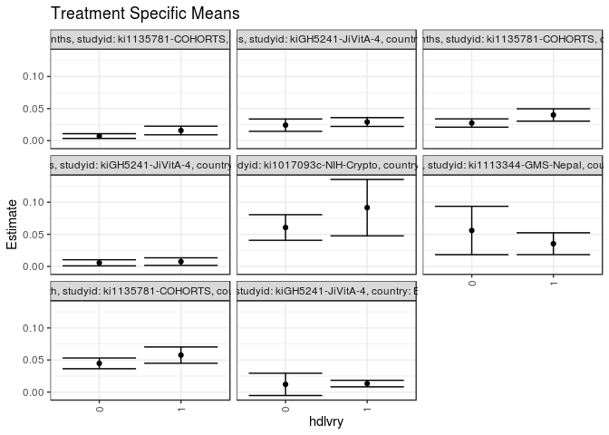

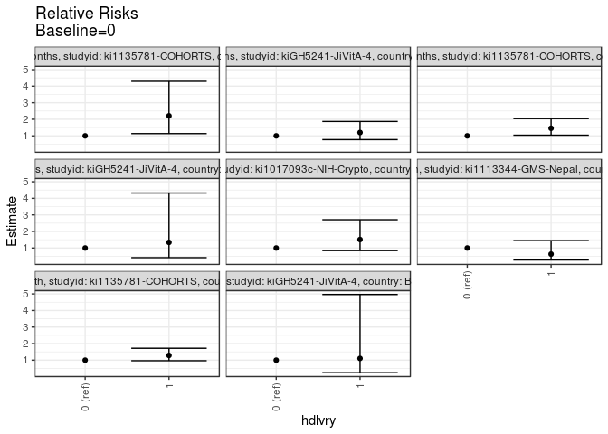

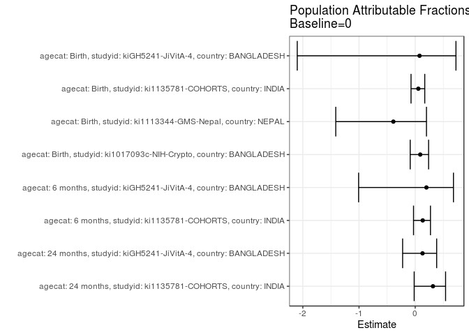

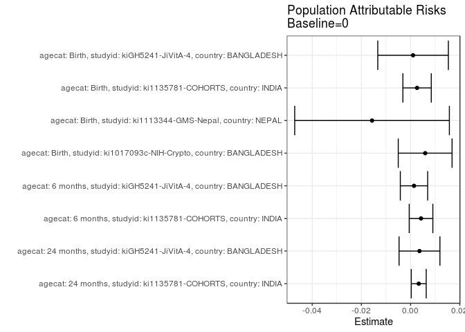

## Results Table

### Parameter: TSM

| agecat | studyid | country | intervention_level | baseline_level | estimate | ci_lower | ci_upper |
| --- | --- | --- | --- | --- | --- | --- | --- |
| Birth | ki1017093c-NIH-Crypto | BANGLADESH | 0 | NA | 0.0605541 | 0.0405910 | 0.0805173 |
| Birth | ki1017093c-NIH-Crypto | BANGLADESH | 1 | NA | 0.0915255 | 0.0475805 | 0.1354705 |
| Birth | ki1113344-GMS-Nepal | NEPAL | 0 | NA | 0.0559441 | 0.0182459 | 0.0936423 |
| Birth | ki1113344-GMS-Nepal | NEPAL | 1 | NA | 0.0353201 | 0.0183077 | 0.0523325 |
| Birth | ki1135781-COHORTS | INDIA | 0 | NA | 0.0447591 | 0.0364248 | 0.0530934 |
| Birth | ki1135781-COHORTS | INDIA | 1 | NA | 0.0576375 | 0.0449572 | 0.0703179 |
| Birth | kiGH5241-JiVitA-4 | BANGLADESH | 0 | NA | 0.0120000 | -0.0054099 | 0.0294099 |
| Birth | kiGH5241-JiVitA-4 | BANGLADESH | 1 | NA | 0.0132696 | 0.0081641 | 0.0183752 |
| 6 months | ki1135781-COHORTS | INDIA | 0 | NA | 0.0274963 | 0.0210297 | 0.0339628 |
| 6 months | ki1135781-COHORTS | INDIA | 1 | NA | 0.0400510 | 0.0304384 | 0.0496636 |
| 6 months | kiGH5241-JiVitA-4 | BANGLADESH | 0 | NA | 0.0055453 | 0.0008107 | 0.0102799 |
| 6 months | kiGH5241-JiVitA-4 | BANGLADESH | 1 | NA | 0.0074324 | 0.0015459 | 0.0133190 |
| 24 months | ki1135781-COHORTS | INDIA | 0 | NA | 0.0071654 | 0.0035013 | 0.0108295 |
| 24 months | ki1135781-COHORTS | INDIA | 1 | NA | 0.0158090 | 0.0090788 | 0.0225391 |
| 24 months | kiGH5241-JiVitA-4 | BANGLADESH | 0 | NA | 0.0241828 | 0.0145787 | 0.0337870 |
| 24 months | kiGH5241-JiVitA-4 | BANGLADESH | 1 | NA | 0.0290385 | 0.0222029 | 0.0358742 |

### Parameter: E(Y)

| agecat | studyid | country | intervention_level | baseline_level | estimate | ci_lower | ci_upper |
| --- | --- | --- | --- | --- | --- | --- | --- |
| Birth | ki1017093c-NIH-Crypto | BANGLADESH | NA | NA | 0.0664781 | 0.0481022 | 0.0848539 |
| Birth | ki1113344-GMS-Nepal | NEPAL | NA | NA | 0.0402685 | 0.0244725 | 0.0560645 |
| Birth | ki1135781-COHORTS | INDIA | NA | NA | 0.0473912 | 0.0411045 | 0.0536779 |
| Birth | kiGH5241-JiVitA-4 | BANGLADESH | NA | NA | 0.0130034 | 0.0075709 | 0.0184358 |
| 6 months | ki1135781-COHORTS | INDIA | NA | NA | 0.0317427 | 0.0267269 | 0.0367584 |
| 6 months | kiGH5241-JiVitA-4 | BANGLADESH | NA | NA | 0.0069273 | 0.0024440 | 0.0114105 |
| 24 months | ki1135781-COHORTS | INDIA | NA | NA | 0.0104727 | 0.0071155 | 0.0138299 |
| 24 months | kiGH5241-JiVitA-4 | BANGLADESH | NA | NA | 0.0277986 | 0.0219343 | 0.0336630 |

### Parameter: RR

| agecat | studyid | country | intervention_level | baseline_level | estimate | ci_lower | ci_upper |
| --- | --- | --- | --- | --- | --- | --- | --- |
| Birth | ki1017093c-NIH-Crypto | BANGLADESH | 0 | 0 | 1.0000000 | 1.0000000 | 1.000000 |
| Birth | ki1017093c-NIH-Crypto | BANGLADESH | 1 | 0 | 1.5114656 | 0.8438645 | 2.707222 |
| Birth | ki1113344-GMS-Nepal | NEPAL | 0 | 0 | 1.0000000 | 1.0000000 | 1.000000 |
| Birth | ki1113344-GMS-Nepal | NEPAL | 1 | 0 | 0.6313466 | 0.2757666 | 1.445420 |
| Birth | ki1135781-COHORTS | INDIA | 0 | 0 | 1.0000000 | 1.0000000 | 1.000000 |
| Birth | ki1135781-COHORTS | INDIA | 1 | 0 | 1.2877264 | 0.9654013 | 1.717668 |
| Birth | kiGH5241-JiVitA-4 | BANGLADESH | 0 | 0 | 1.0000000 | 1.0000000 | 1.000000 |
| Birth | kiGH5241-JiVitA-4 | BANGLADESH | 1 | 0 | 1.1058033 | 0.2462205 | 4.966284 |
| 6 months | ki1135781-COHORTS | INDIA | 0 | 0 | 1.0000000 | 1.0000000 | 1.000000 |
| 6 months | ki1135781-COHORTS | INDIA | 1 | 0 | 1.4565970 | 1.0409053 | 2.038298 |
| 6 months | kiGH5241-JiVitA-4 | BANGLADESH | 0 | 0 | 1.0000000 | 1.0000000 | 1.000000 |
| 6 months | kiGH5241-JiVitA-4 | BANGLADESH | 1 | 0 | 1.3403153 | 0.4160078 | 4.318297 |
| 24 months | ki1135781-COHORTS | INDIA | 0 | 0 | 1.0000000 | 1.0000000 | 1.000000 |
| 24 months | ki1135781-COHORTS | INDIA | 1 | 0 | 2.2062885 | 1.1342465 | 4.291579 |
| 24 months | kiGH5241-JiVitA-4 | BANGLADESH | 0 | 0 | 1.0000000 | 1.0000000 | 1.000000 |
| 24 months | kiGH5241-JiVitA-4 | BANGLADESH | 1 | 0 | 1.2007922 | 0.7726658 | 1.866139 |

### Parameter: PAR

| agecat | studyid | country | intervention_level | baseline_level | estimate | ci_lower | ci_upper |
| --- | --- | --- | --- | --- | --- | --- | --- |
| Birth | ki1017093c-NIH-Crypto | BANGLADESH | 0 | NA | 0.0059239 | -0.0050173 | 0.0168652 |
| Birth | ki1113344-GMS-Nepal | NEPAL | 0 | NA | -0.0156756 | -0.0471193 | 0.0157681 |
| Birth | ki1135781-COHORTS | INDIA | 0 | NA | 0.0026321 | -0.0031424 | 0.0084065 |
| Birth | kiGH5241-JiVitA-4 | BANGLADESH | 0 | NA | 0.0010034 | -0.0133484 | 0.0153551 |
| 6 months | ki1135781-COHORTS | INDIA | 0 | NA | 0.0042464 | -0.0005571 | 0.0090498 |
| 6 months | kiGH5241-JiVitA-4 | BANGLADESH | 0 | NA | 0.0013820 | -0.0041754 | 0.0069393 |
| 24 months | ki1135781-COHORTS | INDIA | 0 | NA | 0.0033073 | 0.0002680 | 0.0063465 |
| 24 months | kiGH5241-JiVitA-4 | BANGLADESH | 0 | NA | 0.0036158 | -0.0046943 | 0.0119259 |

### Parameter: PAF

| agecat | studyid | country | intervention_level | baseline_level | estimate | ci_lower | ci_upper |
| --- | --- | --- | --- | --- | --- | --- | --- |
| Birth | ki1017093c-NIH-Crypto | BANGLADESH | 0 | NA | 0.0891111 | -0.0891598 | 0.2382032 |
| Birth | ki1113344-GMS-Nepal | NEPAL | 0 | NA | -0.3892774 | -1.4139478 | 0.2004418 |
| Birth | ki1135781-COHORTS | INDIA | 0 | NA | 0.0555393 | -0.0743760 | 0.1697450 |
| Birth | kiGH5241-JiVitA-4 | BANGLADESH | 0 | NA | 0.0771613 | -2.0994742 | 0.7252336 |
| 6 months | ki1135781-COHORTS | INDIA | 0 | NA | 0.1337756 | -0.0299725 | 0.2714905 |
| 6 months | kiGH5241-JiVitA-4 | BANGLADESH | 0 | NA | 0.1994983 | -1.0071943 | 0.6807469 |
| 24 months | ki1135781-COHORTS | INDIA | 0 | NA | 0.3157992 | -0.0184556 | 0.5403523 |
| 24 months | kiGH5241-JiVitA-4 | BANGLADESH | 0 | NA | 0.1300718 | -0.2239776 | 0.3817084 |